# Mobile

## Importing the required libraries and loading the dataset

```python
# Loading the required libraries

import numpy as np
import pandas as pd
import seaborn as sb
import matplotlib.pyplot as plt
from sklearn.preprocessing import StandardScaler
from sklearn.decomposition import PCA
from sklearn.cluster import KMeans, AgglomerativeClustering
from sklearn.metrics import silhouette_score
from scipy.cluster.hierarchy import dendrogram, linkage
from sklearn.preprocessing import LabelEncoder
import warnings
warnings.filterwarnings('ignore')
```

```python
# Reading the datasets

events = pd.read_csv(r"E:\New folder (3)\Dataset\Copy of events.csv")
gender_age = pd.read_csv(r"E:\New folder (3)\Dataset\Copy of gender_age.csv")
phone_device = pd.read_csv(r"E:\New folder (3)\Dataset\Copy of phone_device.csv")
```

```python
# Checking Shape and Size of the dataset

def shapeSize(*dataset):
    for dataName, data in dataset:
        print(f"Shape of {dataName} Dataset: {data.shape}")
        print(f"Size of {dataName} Dataset: {data.size}")
        print("--------------------------------------------------------")

shapeSize(("Events", events), ("Gender_Age", gender_age), ("Phone_Device", phone_device))
```

```
Shape of Events Dataset: (3252950, 5)
Size of Events Dataset: 16264750
--------------------------------------------------------
Shape of Gender_Age Dataset: (74645, 4)
Size of Gender_Age Dataset: 298580
--------------------------------------------------------
Shape of Phone_Device Dataset: (187245, 3)
Size of Phone_Device Dataset: 561735
--------------------------------------------------------
```

```python
# Checking first few samples of events dataset

events.head()
```

|  | event_id | device_id | timestamp | longitude | latitude |
| --- | --- | --- | --- | --- | --- |
| 0 | 1 | 29182687948017175 | 2016-05-01 00:55:25 | 121.38 | 31.24 |
| 1 | 2 | -6401643145415154744 | 2016-05-01 00:54:12 | 103.65 | 30.97 |
| 2 | 3 | -4833982096941402721 | 2016-05-01 00:08:05 | 106.60 | 29.70 |
| 3 | 4 | -6815121365017318426 | 2016-05-01 00:06:40 | 104.27 | 23.28 |
| 4 | 5 | -5373797595892518570 | 2016-05-01 00:07:18 | 115.88 | 28.66 |

```python
# Checking the info of events dataset

events.info()
```

```
<class 'pandas.core.frame.DataFrame'>
RangeIndex: 3252950 entries, 0 to 3252949
Data columns (total 5 columns):
 #   Column     Dtype
---  ------     -----
 0   event_id   int64
 1   device_id  int64
 2   timestamp  object
 3   longitude  float64
 4   latitude   float64
dtypes: float64(2), int64(2), object(1)
memory usage: 124.1+ MB
```

```python
# Checking first few sample of gender_age dataset

gender_age.head()
```

|  | device_id | gender | age | group |
| --- | --- | --- | --- | --- |
| 0 | -8076087639492063270 | M | 35 | M32-38 |
| 1 | -2897161552818060146 | M | 35 | M32-38 |
| 2 | -8260683887967679142 | M | 35 | M32-38 |
| 3 | -4938849341048082022 | M | 30 | M29-31 |
| 4 | 245133531816851882 | M | 30 | M29-31 |

```python
# Checking the info of gender_age dataset

gender_age.info()
```

```
<class 'pandas.core.frame.DataFrame'>
RangeIndex: 74645 entries, 0 to 74644
Data columns (total 4 columns):
 #   Column     Non-Null Count  Dtype
---  ------     --------------  -----
 0   device_id  74645 non-null  int64
 1   gender     74645 non-null  object
 2   age        74645 non-null  int64
 3   group      74645 non-null  object
dtypes: int64(2), object(2)
memory usage: 2.3+ MB
```

```python
# Checking first few samples of phone_device dataset

phone_device.head()
```

|  | device_id | phone_brand | device_model |
| --- | --- | --- | --- |
| 0 | -8890648629457979026 | 小米 | 红米 |
| 1 | 1277779817574759137 | 小米 | MI 2 |
| 2 | 5137427614288105724 | 三星 | Galaxy S4 |
| 3 | 3669464369358936369 | SUGAR | 时尚手机 |
| 4 | -5019277647504317457 | 三星 | Galaxy Note 2 |

```python
# Checking info of phone_device dataset

phone_device.info()
```

```
<class 'pandas.core.frame.DataFrame'>
RangeIndex: 187245 entries, 0 to 187244
Data columns (total 3 columns):
 #   Column        Non-Null Count   Dtype
---  ------        --------------   -----
 0   device_id     187245 non-null  int64
 1   phone_brand   187245 non-null  object
 2   device_model  187245 non-null  object
dtypes: int64(1), object(2)
memory usage: 4.3+ MB
```

## Data cleansing and exploratory data analysis

```python
# Checking if there are any duplicate records in the dataset and if present then dropping them.

def checkDuplicate(*dataset):
    for df_name, df in dataset:
        duplicate_values = df.duplicated().sum()
        print(f"{duplicate_values} duplicate values in {df_name} dataset")
        if duplicate_values > 0:
            print(f"Duplicate values were present in {df_name} and have been removed.")
            df.drop_duplicates(inplace = True)

checkDuplicate(("Events", events), ("Gender_Age", gender_age), ("Phone_Device", phone_device))
```

```
0 duplicate values in Events dataset
0 duplicate values in Gender_Age dataset
523 duplicate values in Phone_Device dataset
Duplicate values were present in Phone_Device and have been removed.
```

```python
# Merging the data into a single dataframe

df = pd.merge(events, gender_age, on = 'device_id')
df = pd.merge(df, phone_device, on = 'device_id')
```

```python
df.head()
```

|  | event_id | device_id | timestamp | longitude | latitude | gender | age | group | phone_brand | device_model |
| --- | --- | --- | --- | --- | --- | --- | --- | --- | --- | --- |
| 0 | 1 | 29182687948017175 | 2016-05-01 00:55:25 | 121.38 | 31.24 | M | 46 | M39+ | 小米 | 红米note |
| 1 | 7104 | 29182687948017175 | 2016-05-02 09:37:02 | 121.38 | 31.24 | M | 46 | M39+ | 小米 | 红米note |
| 2 | 29661 | 29182687948017175 | 2016-05-04 00:56:04 | 121.39 | 31.23 | M | 46 | M39+ | 小米 | 红米note |
| 3 | 33133 | 29182687948017175 | 2016-05-06 05:01:15 | 121.38 | 31.24 | M | 46 | M39+ | 小米 | 红米note |
| 4 | 38980 | 29182687948017175 | 2016-05-06 09:55:04 | 121.16 | 31.00 | M | 46 | M39+ | 小米 | 红米note |

```python
# Checking for null values in each column of the dataset.

df.isnull().sum()
```

```
event_id        0
device_id       0
timestamp       0
longitude       0
latitude        0
gender          0
age             0
group           0
phone_brand     0
device_model    0
dtype: int64
```

```python
# Checking the Statistical summary for numerical columns

def numericalSummary(df):
    print("Statistical summary for Numerical columns.")
    return df.describe()

numericalSummary(df)
```

```
Statistical summary for Numerical columns.
```

|  | event_id | device_id | longitude | latitude | age |
| --- | --- | --- | --- | --- | --- |
| count | 1.215616e+06 | 1.215616e+06 | 1.215616e+06 | 1.215616e+06 | 1.215616e+06 |
| mean | 1.626674e+06 | -3.106798e+16 | 7.839264e+01 | 2.182718e+01 | 3.350004e+01 |
| std | 9.396635e+05 | 5.322372e+18 | 5.381290e+01 | 1.564838e+01 | 9.745614e+00 |
| min | 1.000000e+00 | -9.222957e+18 | -1.800000e+02 | -3.380000e+01 | 1.100000e+01 |
| 25% | 8.123215e+05 | -4.672948e+18 | 0.000000e+00 | 0.000000e+00 | 2.700000e+01 |
| 50% | 1.627308e+06 | -1.173809e+17 | 1.127500e+02 | 2.857000e+01 | 3.100000e+01 |
| 75% | 2.440378e+06 | 4.631837e+18 | 1.171700e+02 | 3.401000e+01 | 3.900000e+01 |
| max | 3.252948e+06 | 9.220915e+18 | 1.511800e+02 | 5.364000e+01 | 8.900000e+01 |

#### OBSERVATION

- **Event IDs** seem to be unique identifiers likely assigned sequentially.
- **Device IDs** had very large mean and standard deviation.
- **Longitude** data likely includes global locations, but some longitude values might be incorrect as 25% of the datapoints have longitude of 0.
- **Latitude** data covers a broad geographical area but might contain some inaccuracies as 25% of the datapoints have latitude of 0.
- **Age** likely focuses on a general adult population, with a concentration of users in their late 20s to late 30s.

```python
# Checking the Statistical Summary for Categorical Columns

def categoricalSummary(df):
    categorical_columns = df.select_dtypes(include=['object']).columns
    print("Statistical Summary for Categorical Columns: \n")
    for col in categorical_columns:
        print(f"Column: {col}\n{df[col].describe()}\n")

categoricalSummary(df)
```

```
Statistical Summary for Categorical Columns:

Column: timestamp
count                 1215616
unique                 497663
top       2016-05-03 10:00:03
freq                       18
Name: timestamp, dtype: object

Column: gender
count     1215616
unique          2
top             M
freq       864324
Name: gender, dtype: object

Column: group
count     1215616
unique         12
top          M39+
freq       211020
Name: group, dtype: object

Column: phone_brand
count     1215616
unique         89
top            华为
freq       375959
Name: phone_brand, dtype: object

Column: device_model
count     1215616
unique        926
top           荣耀6
freq        54987
Name: device_model, dtype: object
```

#### OBSERVATION

- The **timestamp data** has some repetition, but with a high number of unique values. The frequency of the top timestamp is low, so no significant clustering around specific times is observed.
- There is a **gender** imbalance in the data, with males being the dominant gender.
- **Group data** has diverse group classifications, with a significant portion of users belonging to the "M39+" group.
- In **Phone Brand**, there is a dominant preference for Huawei phones among the users.
- **Device Model data** has a wide range of device models, with the Honor 6 model being particularly popular.

### Univariate Analysis

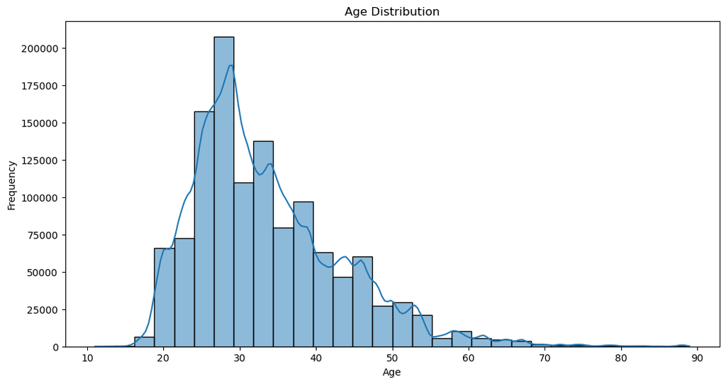

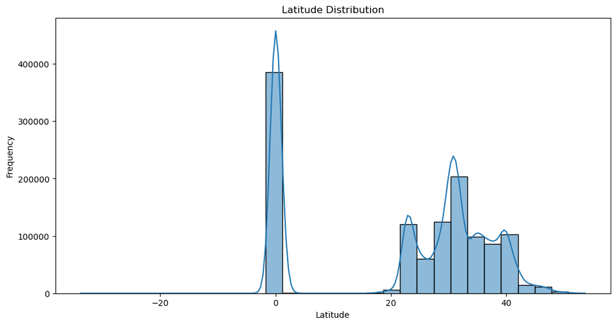

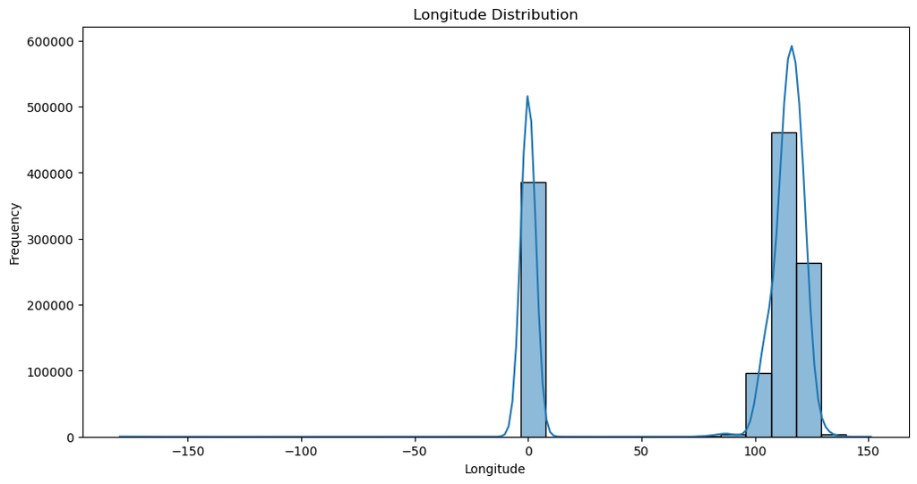

```python
# Plotting Histogram for numerical columns

def numHist():
    num_col = [('Age', 'age'), ('Latitude', 'latitude'), ('Longitude', 'longitude')]
    for colName, col in num_col:
        plt.figure(figsize = (12, 6))
        sb.histplot(df[col].dropna(), kde = True, bins = 30)
        plt.title(f'{colName} Distribution')
        plt.xlabel(colName)
        plt.ylabel('Frequency')
        plt.show()

numHist()
```

#### OBSERVATION

- **Age Distribution:** The graph indicates a peak population age between 25 and 35 years old. A notable decline in population is observed after the age of 40.
- **Latitude Distribution:** The majority of the geographic data is concentrated between latitudes 20 and 45 degrees. However, there are some potential outliers with latitude values of 0, which may contain errors.
- **Longitude Distribution:** The primary geographic focus lies between longitudes 100 and 140 degrees. Similar to latitude, there are instances of 0 longitude values that might be inaccurate.

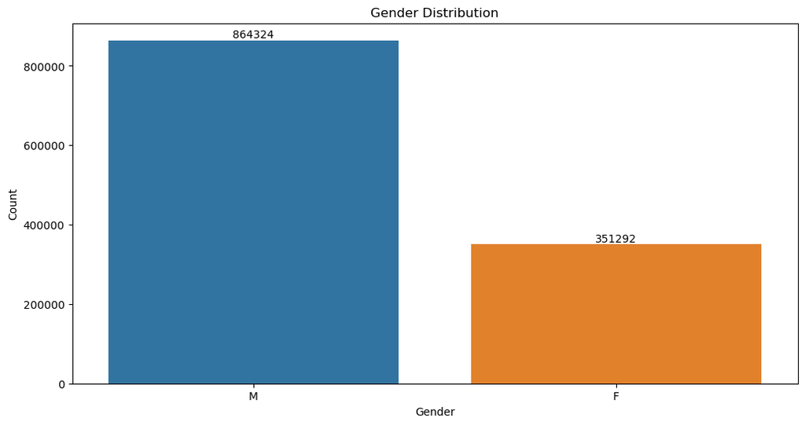

```python
# PLotting Countplot for Gender Distribution

plt.figure(figsize = (12, 6))
x = sb.countplot(x = 'gender', data = df)
for p in x.patches:
    val = p.get_height()
    x.text(p.get_x() + p.get_width() / 2., val, int(val), ha = "center", va = "bottom")
plt.title('Gender Distribution')
plt.xlabel('Gender')
plt.ylabel('Count')
plt.show()
```

#### OBSERVATION

- There is a gender imbalance in the data, with males being the dominant gender(864324).

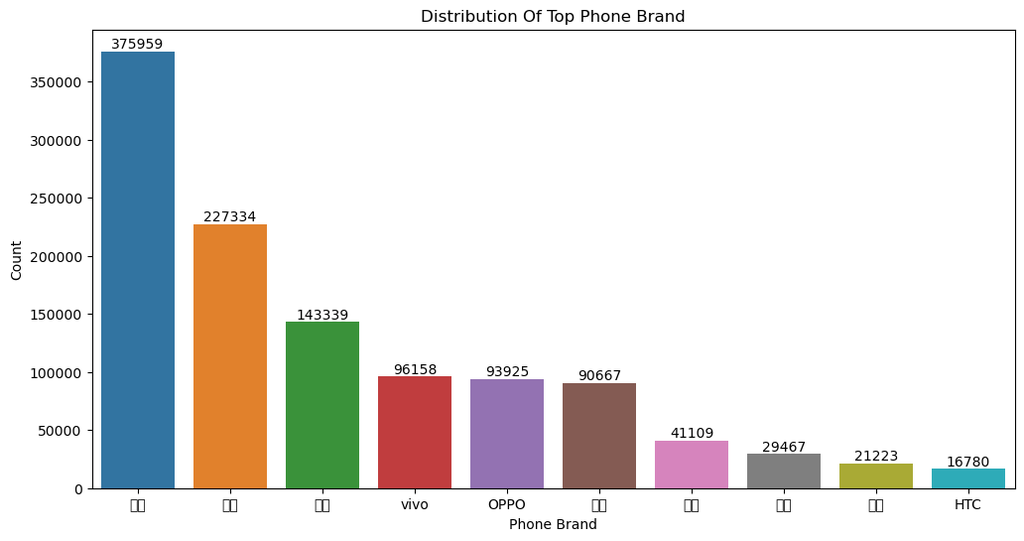

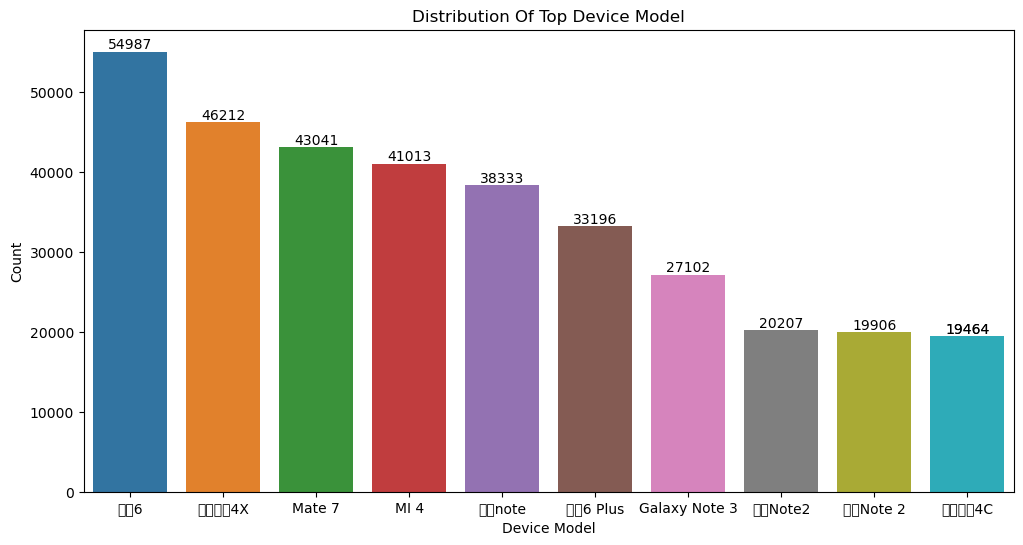

```python
# Getting top 10 Phone Brand and Device Model using Barplot

top_10_phoneBrand = df['phone_brand'].value_counts().nlargest(10)
top_10_deviceModel = df['device_model'].value_counts().nlargest(10)

plt.figure(figsize = (12, 6))
ax = sb.barplot(x = top_10_phoneBrand.index, y = top_10_phoneBrand.values, data = df)
for p in ax.patches:
    height = p.get_height()
    ax.text(p.get_x() + p.get_width() / 2., height, int(height), ha = "center", va = "bottom")
plt.title('Distribution Of Top Phone Brand')
plt.xlabel('Phone Brand')
plt.ylabel('Count')
plt.show()

plt.figure(figsize = (12, 6))
ax = sb.barplot(x = top_10_deviceModel.index, y = top_10_deviceModel.values, data = df)
for p in ax.patches:
    height = p.get_height()
    ax.text(p.get_x() + p.get_width() / 2., height, int(height), ha = "center", va = "bottom")
height = p.get_height()
ax.text(p.get_x() + p.get_width() / 2., height, int(height), ha = "center", va = "bottom")
plt.title('Distribution Of Top Device Model')
plt.xlabel('Device Model')
plt.ylabel('Count')
plt.show()
```

### Bivariate Analysis

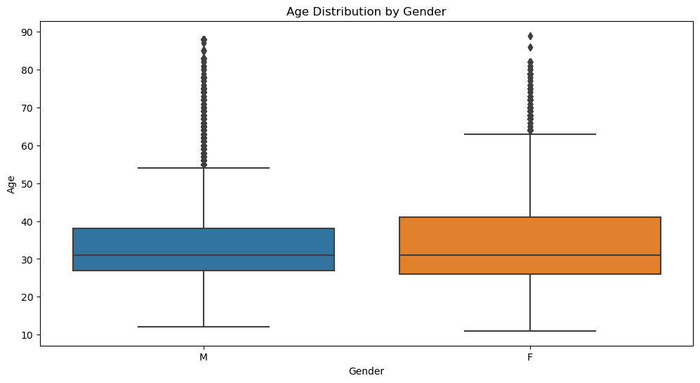

```python
# PLotting Boxplot for Age Distribution by Gender

plt.figure(figsize = (12, 6))
sb.boxplot(x = 'gender', y = 'age', data = df)
plt.title('Age Distribution by Gender')
plt.xlabel('Gender')
plt.ylabel('Age')
plt.show()
```

#### OBSERVATION

- The median age for both males and females in the dataset is approximately 32 years old. However, the data contains numerous outliers, with male ages exceeding 55 and female ages surpassing 65.

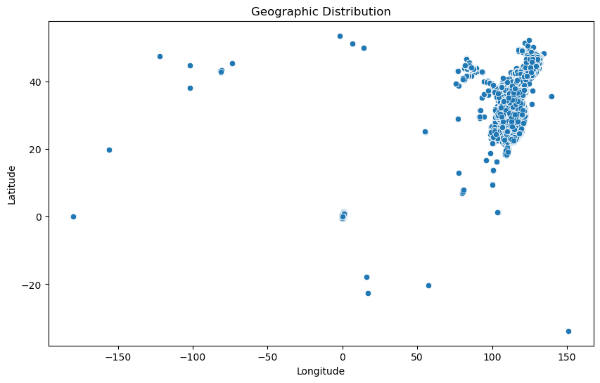

```python
# Plotting Scatter plot for geographic distribution

plt.figure(figsize = (10, 6))
sb.scatterplot(data = df, x = 'longitude', y = 'latitude', palette = 'tab10')
plt.title('Geographic Distribution')
plt.xlabel("Longitude")
plt.ylabel("Latitude")
plt.show()
```

#### OBSERVATION

- The maximum geographical coordinates for this dataset fall within a longitude range of 100 to 140 degrees and a latitude range of 20 to 45 degrees.

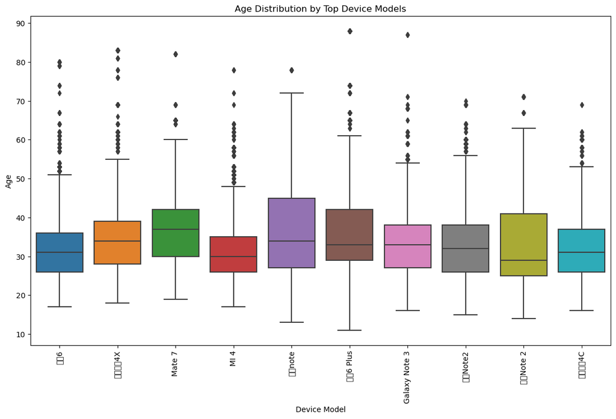

```python
# PLotting a Boxplot for Age vs Top Device Models

plt.figure(figsize = (14, 8))
sb.boxplot(x = 'device_model', y = 'age', order = top_10_deviceModel.index, data = df)
plt.xticks(rotation = 90)
plt.title('Age Distribution by Top Device Models')
plt.xlabel('Device Model')
plt.ylabel('Age')
plt.show()
```

#### OBSERVATION

- Among the device models, Mate 7, Note, and Note 2 exhibit the fewest outliers in age distribution, while the remaining models have significantly more.

### Multivariate Analysis

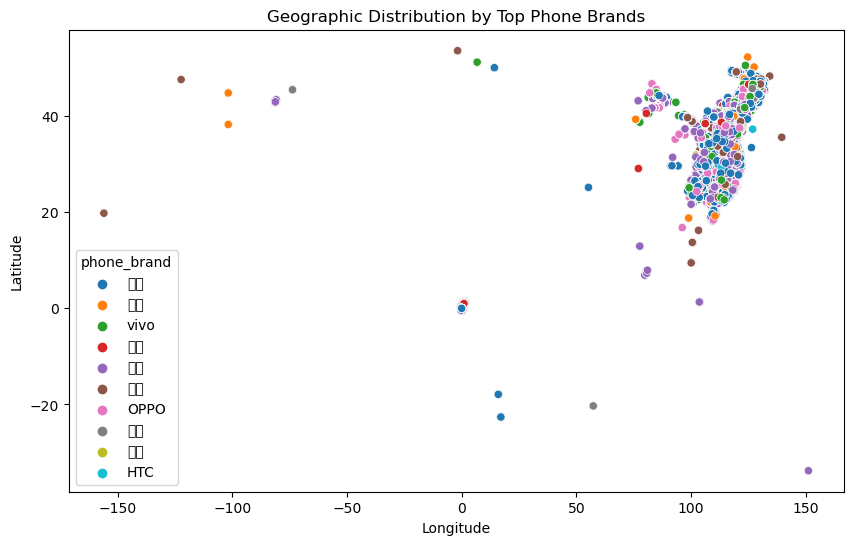

```python
# PLotting a Scatter plot Longitude vs. Latitude for Top Phone Brands

filtered_df = df[df['phone_brand'].isin(top_10_phoneBrand.index)]
plt.figure(figsize = (10, 6))
sb.scatterplot(data = filtered_df, x = 'longitude', y = 'latitude', hue = 'phone_brand', palette = 'tab10')
plt.title('Geographic Distribution by Top Phone Brands')
plt.xlabel("Longitude")
plt.ylabel("Latitude")
plt.show()
```

#### OBSERVATION

- Most of the users of top phone brands are concentrated in similar geographic areas.

```python
# Encoding Categorical Variables in the dataset

def objToInt(df_series):
    if df_series.dtype == 'object':
        df_series = LabelEncoder().fit_transform(df_series)
    return df_series

dfCopy = df.copy()
encoded_df = dfCopy.apply(lambda x: objToInt(x))
encoded_df.head()
```

|  | event_id | device_id | timestamp | longitude | latitude | gender | age | group | phone_brand | device_model |
| --- | --- | --- | --- | --- | --- | --- | --- | --- | --- | --- |
| 0 | 1 | 29182687948017175 | 3013 | 121.38 | 31.24 | 1 | 46 | 11 | 34 | 864 |
| 1 | 7104 | 29182687948017175 | 95043 | 121.38 | 31.24 | 1 | 46 | 11 | 34 | 864 |
| 2 | 29661 | 29182687948017175 | 215278 | 121.39 | 31.23 | 1 | 46 | 11 | 34 | 864 |
| 3 | 33133 | 29182687948017175 | 366491 | 121.38 | 31.24 | 1 | 46 | 11 | 34 | 864 |
| 4 | 38980 | 29182687948017175 | 381396 | 121.16 | 31.00 | 1 | 46 | 11 | 34 | 864 |

```python
# Dropping irrelevant columns in the encoded dataset and original dataset.

encoded_df.drop(['event_id', 'device_id', 'timestamp'], axis = 1, inplace = True)
df.drop(['event_id', 'device_id', 'timestamp'], axis = 1, inplace = True)
```

## Data Preparation for model building

```python
# Standardizing the data, so that they are within a particular range

scaler = StandardScaler()
scaled_array = scaler.fit_transform(encoded_df)
scaled_df = pd.DataFrame(scaled_array, columns = encoded_df.columns)
scaled_df.head()
```

|  | longitude | latitude | gender | age | group | phone_brand | device_model |
| --- | --- | --- | --- | --- | --- | --- | --- |
| 0 | 0.798830 | 0.601520 | 0.637523 | 1.282625 | 1.148623 | 0.228518 | 0.930054 |
| 1 | 0.798830 | 0.601520 | 0.637523 | 1.282625 | 1.148623 | 0.228518 | 0.930054 |
| 2 | 0.799016 | 0.600881 | 0.637523 | 1.282625 | 1.148623 | 0.228518 | 0.930054 |
| 3 | 0.798830 | 0.601520 | 0.637523 | 1.282625 | 1.148623 | 0.228518 | 0.930054 |
| 4 | 0.794742 | 0.586183 | 0.637523 | 1.282625 | 1.148623 | 0.228518 | 0.930054 |

```python
# Taking a sample_size of 5000 for further process to avoid computation issues.

sample_size = 5000
df_sample = scaled_df.sample(n = sample_size, random_state = 45)
```

## Principal Component Analysis and Clustering

#### PCA

```python
# Covariance Matrix

cov_matrix = np.cov(df_sample.T)
print('Covariance matrix', '\n', cov_matrix)
```

```
Covariance matrix
 [[ 1.01811961  0.96539955  0.0534027  -0.01548584  0.04178201 -0.09812405
   0.07325635]
 [ 0.96539955  1.01381239  0.03166385  0.00336976  0.03191925 -0.10648475
   0.0629288 ]
 [ 0.0534027   0.03166385  1.00350986 -0.05231561  0.8539933   0.07092668
   0.05826778]
 [-0.01548584  0.00336976 -0.05231561  1.00240706  0.39430425 -0.01834217
  -0.01609702]
 [ 0.04178201  0.03191925  0.8539933   0.39430425  0.98651914  0.04429845
   0.04118081]
 [-0.09812405 -0.10648475  0.07092668 -0.01834217  0.04429845  1.02543148
   0.16254302]
 [ 0.07325635  0.0629288   0.05826778 -0.01609702  0.04118081  0.16254302
   1.0004998 ]]
```

```python
# Eigen Values and Eigen Vectors

eig_vals, eig_vecs = np.linalg.eig(cov_matrix)

print('Eigen vectors:','\n',eig_vecs)
print('\n')
print('Eigen values:','\n',eig_vals)
```

```
Eigen vectors:
 [[-0.611577   -0.338491   -0.70612945  0.02382768  0.1026631   0.03688454
   0.01762607]
 [-0.60572616 -0.34601466  0.70699033 -0.02392274  0.10571647  0.01922539
   0.03763594]
 [-0.33160202  0.55588494 -0.01026428 -0.63614865 -0.02450319  0.08217788
  -0.4109598 ]
 [-0.10817756  0.23880633 -0.02558145 -0.31925828  0.03469409 -0.37766862
   0.82755763]
 [-0.35034758  0.61057237  0.02708228  0.70155962 -0.01239312 -0.10669234
   0.00132782]
 [ 0.06983552  0.15963686  0.00419563  0.00778294  0.69175509  0.65909107
   0.23798058]
 [-0.09892765  0.0371298   0.00592131  0.0015844  -0.70555052  0.63490065
   0.29647387]]


Eigen values:
 [2.0474893  1.89107646 0.05012459 0.0336285  0.82458508 1.18559411
 1.0178013 ]
```

```python
# Variance Explained and Cummulative Variance Explained

total = sum(eig_vals)
var_exp = [ (i / total) * 100  for i in sorted(eig_vals, reverse = True)]
cum_var_exp = np.cumsum(var_exp)
print('Variance Explained: ', var_exp)
print('Cummulative Variance Explained: ', cum_var_exp)
```

```
Variance Explained:  [29.041168302454512, 26.82264070562445, 16.81622370329392, 14.43628498737803, 11.695745704638469, 0.7109568604646587, 0.4769797361459516]
Cummulative Variance Explained:  [ 29.0411683   55.86380901  72.68003271  87.1163177   98.8120634
  99.52302026 100.        ]
```

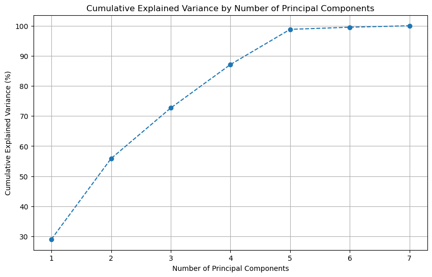

```python
# Plotting a Line plot between Number of Principal Component and Cummulative Explained Variance

plt.figure(figsize = (10, 6))
plt.plot(np.arange(1, len(cum_var_exp) + 1), cum_var_exp, marker = 'o', linestyle = '--')
plt.xlabel('Number of Principal Components')
plt.ylabel('Cumulative Explained Variance (%)')
plt.title('Cumulative Explained Variance by Number of Principal Components')
plt.grid()
plt.show()
```

```python
# Applying PCA on the dataset usng PCA component as 5.

pca = PCA(n_components = 5)
pca_df = pca.fit_transform(df_sample)
pca_data = pd.DataFrame(pca_df, columns = [f'PC{i + 1}' for i in range(5)])
print(pca.explained_variance_ratio_)
```

```
[0.29041168 0.26822641 0.16816224 0.14436285 0.11695746]
```

```python
pca_data.head()
```

|  | PC1 | PC2 | PC3 | PC4 | PC5 |
| --- | --- | --- | --- | --- | --- |
| 0 | -1.475441 | 0.571088 | 0.914052 | -1.274954 | 0.499987 |
| 1 | 1.091903 | -1.782200 | -0.362587 | -0.240997 | -1.227655 |
| 2 | -0.891949 | 0.549505 | 0.871688 | -1.520542 | 1.131274 |
| 3 | -0.329416 | 2.431598 | -0.388743 | 0.746237 | -0.888948 |
| 4 | 0.103961 | 1.779149 | -0.355384 | 1.114319 | -0.763438 |

#### Observation

- By retaining the first five principal components, we effectively reduced the dimensionality of the data while preserving approximately 98.81% of the original variance. This reduction simplifies the dataset without significant loss of information.

#### K-Means Clustering

```python
#

cluster_range = range(1, 15)
cluster_error = []
for val in cluster_range:
    clusters = KMeans(n_clusters = val, n_init = 10)
    clusters.fit(pca_data)

    labels = clusters.labels_
    centroid = clusters.cluster_centers_

    cluster_error.append(clusters.inertia_)

clusters_df = pd.DataFrame({'num_clusters': cluster_range, 'cluster_errors': cluster_error})
clusters_df
```

|  | num_clusters | cluster_errors |
| --- | --- | --- |
| 0 | 1 | 34825.764709 |
| 1 | 2 | 25130.650750 |
| 2 | 3 | 19453.847214 |
| 3 | 4 | 16439.152378 |
| 4 | 5 | 14431.826429 |
| 5 | 6 | 12751.284396 |
| 6 | 7 | 11488.705089 |
| 7 | 8 | 10813.911028 |
| 8 | 9 | 9793.224206 |
| 9 | 10 | 8910.049706 |
| 10 | 11 | 8350.040279 |
| 11 | 12 | 7881.286989 |
| 12 | 13 | 7376.489262 |
| 13 | 14 | 6946.962901 |

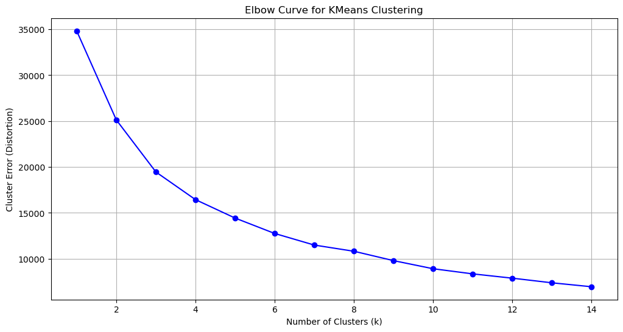

```python
# Finding the optimal K Value using elbow plot for K means clustering.

plt.figure(figsize = (12, 6))
plt.plot(clusters_df['num_clusters'], clusters_df['cluster_errors'], marker = 'o',color = 'b')
plt.xlabel('Number of Clusters (k)')
plt.ylabel('Cluster Error (Distortion)')
plt.title('Elbow Curve for KMeans Clustering')
plt.grid(True)
plt.show()
```

```python
# Building a K means clustering model using the obtained optimal K value from the elbow plot.

kmeans = KMeans(n_clusters = 3, n_init = 15, random_state = 2)
kmeans.fit(pca_data)
```

```
KMeans(n_clusters=3, n_init=15, random_state=2)
```

```python
# Obtaining labels from Kmeans Clustering

kmeans.labels_
```

```
array([1, 2, 1, ..., 1, 1, 1])
```

```python
# Creating a new dataframe only for labels

df_label = pd.DataFrame(kmeans.labels_, columns = list(['Labels']))
df_label.head(5)
```

|  | Labels |
| --- | --- |
| 0 | 1 |
| 1 | 2 |
| 2 | 1 |
| 3 | 0 |
| 4 | 0 |

```python
# Merging the Original Sampled Data with the K-Means Label

original_df = df.sample(n = 5000, random_state = 45)
original_df = original_df.reset_index(drop = True)
df_label = df_label.reset_index(drop = True)
df_kmeans = original_df.merge(df_label, left_index = True, right_index = True)
df_kmeans.head()
```

|  | longitude | latitude | gender | age | group | phone_brand | device_model | Labels |
| --- | --- | --- | --- | --- | --- | --- | --- | --- |
| 0 | 123.47 | 41.83 | M | 27 | M27-28 | 三星 | Galaxy Note 3 | 1 |
| 1 | 0.00 | 0.00 | M | 32 | M32-38 | 华为 | 荣耀6 | 2 |
| 2 | 113.79 | 35.18 | M | 25 | M23-26 | 华为 | Ascend P7 | 1 |
| 3 | 117.11 | 40.14 | F | 32 | F29-32 | 乐视 | 超级手机1 | 0 |
| 4 | 112.56 | 26.91 | F | 36 | F33-42 | 华为 | 荣耀畅玩4C | 0 |

```python
df_kmeans['Labels'].value_counts()
```

```
Labels
1    2434
0    1453
2    1113
Name: count, dtype: int64
```

```python
# Computing silhouette score for evaluating the quality of the K means clustering technique.

for i in range(2, 15):
    kmeans = KMeans(n_clusters = i)
    kmeans = kmeans.fit(pca_data)
    labels = kmeans.predict(pca_data)
    silhouette = silhouette_score(pca_data, labels)
    print(i, silhouette)
```

```
2 0.31812006347121685
3 0.3409238717098168
4 0.37590750617757673
5 0.32384544989282354
6 0.3379514663699795
7 0.3572898733805964
8 0.35418419828451836
9 0.35055538889433185
10 0.3492734025485044
11 0.3496528712173619
12 0.33042495592065435
13 0.35351735785286403
14 0.3430460893886641
```

#### OBSERVATION

- An analysis of the elbow plot indicates an optimal cluster number of 3. And considering the silhouette score, a cluster count of 4 (silhouette_score = 0.375) is suitable for the data.

#### Agglomerative Clustering

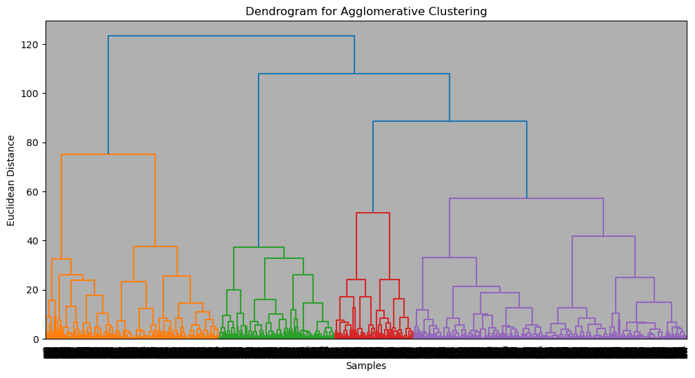

```python
# Finding the optimal K Value using dendrogram for Agglomerative clustering.

linked = linkage(pca_data, method = 'ward')
plt.figure(figsize = (12, 6))
dendrogram(linked)
plt.title("Dendrogram for Agglomerative Clustering")
plt.xlabel("Samples")
plt.ylabel("Euclidean Distance")
plt.grid(True)
plt.show()
```

```python
# Building a Agglomerative clustering model using the obtained optimal K value observed from dendrogram.

optimal_k = 4
cluster_agg = AgglomerativeClustering(n_clusters = optimal_k, affinity = 'euclidean', linkage = 'ward')
cluster_agg_model = cluster_agg.fit(pca_data)
```

```python
# Creating a dataframe of labels

df1_label = pd.DataFrame(cluster_agg_model.labels_, columns = ['Labels'])
df1_label.head()
```

|  | Labels |
| --- | --- |
| 0 | 1 |
| 1 | 0 |
| 2 | 1 |
| 3 | 2 |
| 4 | 2 |

```python
# Merging the sampled data with Agglomerative label

original_df = original_df.reset_index(drop = True)
df_label = df_label.reset_index(drop = True)
df_agg = original_df.merge(df1_label, left_index = True, right_index = True)
df_agg.head()
```

|  | longitude | latitude | gender | age | group | phone_brand | device_model | Labels |
| --- | --- | --- | --- | --- | --- | --- | --- | --- |
| 0 | 123.47 | 41.83 | M | 27 | M27-28 | 三星 | Galaxy Note 3 | 1 |
| 1 | 0.00 | 0.00 | M | 32 | M32-38 | 华为 | 荣耀6 | 0 |
| 2 | 113.79 | 35.18 | M | 25 | M23-26 | 华为 | Ascend P7 | 1 |
| 3 | 117.11 | 40.14 | F | 32 | F29-32 | 乐视 | 超级手机1 | 2 |
| 4 | 112.56 | 26.91 | F | 36 | F33-42 | 华为 | 荣耀畅玩4C | 2 |

```python
df_agg['Labels'].value_counts()
```

```
Labels
1    2129
0    1356
2     901
3     614
Name: count, dtype: int64
```

```python
# Computing silhouette score for evaluating the quality of the Agglomerative clustering technique.

for i in range(2, 15):
    hier = AgglomerativeClustering(n_clusters = i)
    hier = hier.fit(pca_data)
    label = hier.fit_predict(pca_data)
    print(i, silhouette_score(pca_data, label))
```

```
2 0.27356707367805255
3 0.2981105273707586
4 0.34047605622907723
5 0.37726840498578806
6 0.3204013303726747
7 0.3418230513174167
8 0.3171639662567265
9 0.3088035990791269
10 0.3011847291973927
11 0.29872572101597633
12 0.30015219742100624
13 0.3095739198229595
14 0.3149298638592598
```

#### OBSERVATION

- An analysis of the dendrogram indicates an optimal cluster number of 4. However, considering the silhouette score, a cluster count of 5 (silhouette_score = 0.377) might be more suitable for the data.

### Cluster Analysis

#### 1. K-Means Cluster Analysis

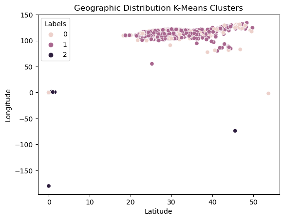

```python
sb.scatterplot(data = df_kmeans, x = 'latitude', y = 'longitude', hue = 'Labels')
plt.title('Geographic Distribution K-Means Clusters')
plt.xlabel('Latitude')
plt.ylabel('Longitude')
plt.show()
```

#### Observation

- Label 0 shows a geographical concentration at higher latitudes and longitudes, Label 1 is more scattered with a slightly lower latitude than Label 0, and Label 2 has only a few points concentrated in the bottom left corner at significantly lower latitudes and longitudes.

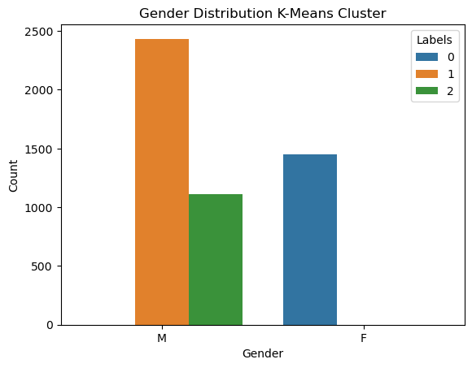

```python
sb.countplot(data = df_kmeans, x = 'gender', hue = 'Labels')
plt.title('Gender Distribution K-Means Cluster')
plt.xlabel('Gender')
plt.ylabel('Count')
plt.show()
```

#### Observation

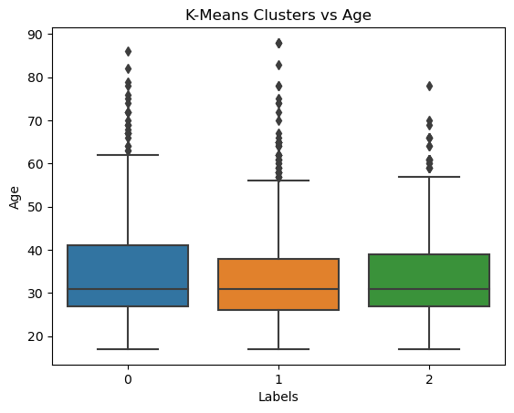

```python
sb.boxplot(x = 'Labels', y = 'age', data = df_kmeans)
plt.title('K-Means Clusters vs Age')
plt.xlabel('Labels')
plt.ylabel('Age')
plt.show()
```

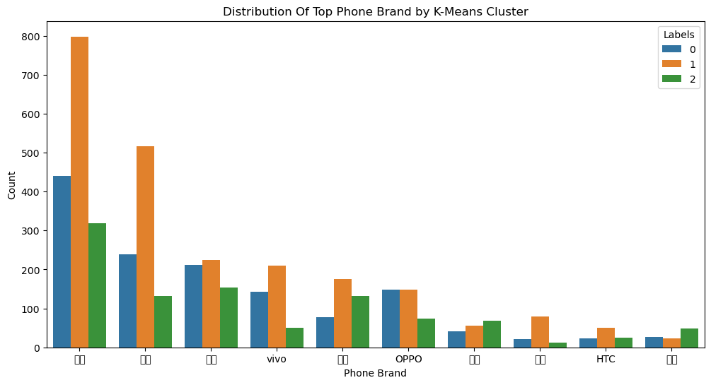

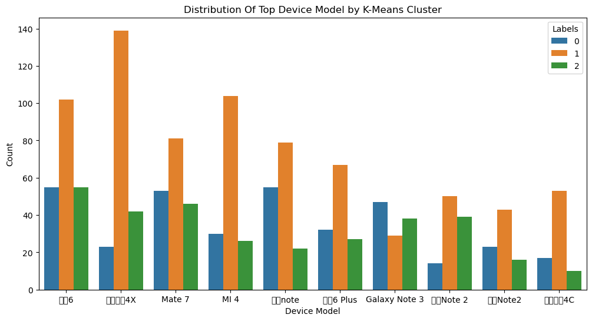

```python
# Top 10 phone brands and device models from df_kmeans

top_10_phoneBrand = df_kmeans['phone_brand'].value_counts().nlargest(10).index
top_10_deviceModel = df_kmeans['device_model'].value_counts().nlargest(10).index

# Filtering the DataFrame for top 10 phone brands and device models
df_top_brands = df_kmeans[df_kmeans['phone_brand'].isin(top_10_phoneBrand)]
df_top_models = df_kmeans[df_kmeans['device_model'].isin(top_10_deviceModel)]

# Plotting for top 10 phone brands
plt.figure(figsize = (12, 6))
sb.countplot(data = df_top_brands, x = 'phone_brand', hue = 'Labels', order = top_10_phoneBrand)
plt.title('Distribution Of Top Phone Brand by K-Means Cluster')
plt.xlabel('Phone Brand')
plt.ylabel('Count')
plt.show()

# Plotting for top 10 device models
plt.figure(figsize = (12, 6))
sb.countplot(data = df_top_models, x = 'device_model', hue = 'Labels', order = top_10_deviceModel)
plt.title('Distribution Of Top Device Model by K-Means Cluster')
plt.xlabel('Device Model')
plt.ylabel('Count')
plt.show()
```

#### 2. Agglomerative Cluster Analysis

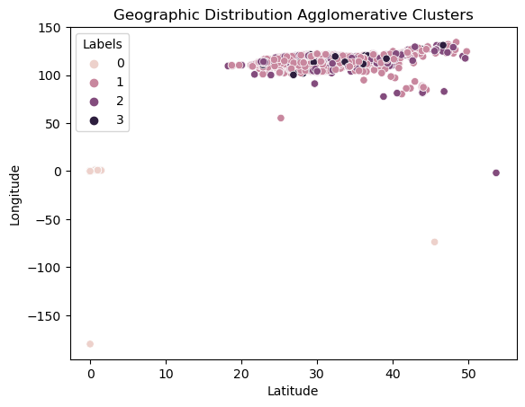

```python
sb.scatterplot(data = df_agg, x = 'latitude', y = 'longitude', hue = 'Labels')
plt.title('Geographic Distribution Agglomerative Clusters')
plt.xlabel('Latitude')
plt.ylabel('Longitude')
plt.show()
```

#### Observation

- Cluster 0 is mostly concentrated in the lower left quadrant of the graph. Cluster 1 and 2 is mostly concentrated in the upper right quadrant of the graph. It appears to have a narrower range of longitudes, but a wider range of latitudes. Cluster 2 is overlapping with cluster 1. Cluster 3 is mainly concentrated in the higher latitude and longitude.

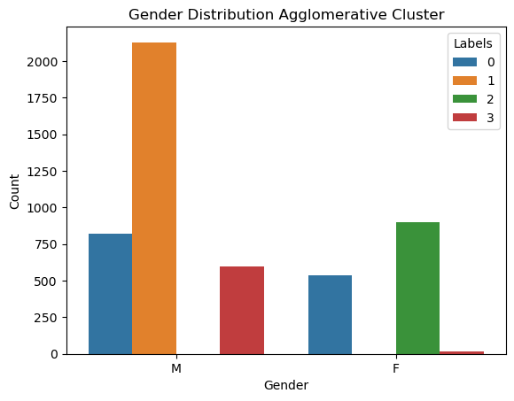

```python
sb.countplot(data = df_agg, x = 'gender', hue = 'Labels')
plt.title('Gender Distribution Agglomerative Cluster')
plt.xlabel('Gender')
plt.ylabel('Count')
plt.show()
```

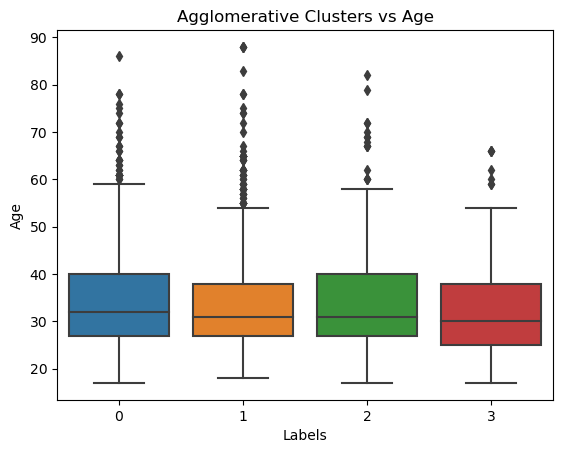

```python
sb.boxplot(x = 'Labels', y = 'age', data = df_agg)
plt.title('Agglomerative Clusters vs Age')
plt.xlabel('Labels')
plt.ylabel('Age')
plt.show()
```

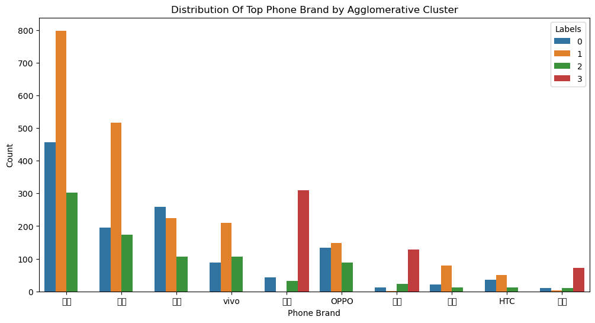

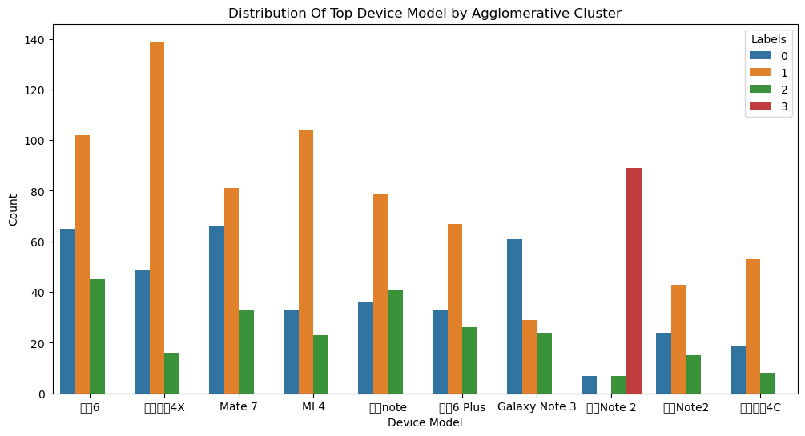

```python
# Top 10 phone brands and device models from df_kmeans

top_10_phoneBrand = df_agg['phone_brand'].value_counts().nlargest(10).index
top_10_deviceModel = df_agg['device_model'].value_counts().nlargest(10).index

# Filtering the DataFrame for top 10 phone brands and device models
df_top_brands = df_agg[df_agg['phone_brand'].isin(top_10_phoneBrand)]
df_top_models = df_agg[df_agg['device_model'].isin(top_10_deviceModel)]

# Plotting for top 10 phone brands
plt.figure(figsize = (12, 6))
sb.countplot(data = df_top_brands, x = 'phone_brand', hue = 'Labels', order = top_10_phoneBrand)
plt.title('Distribution Of Top Phone Brand by Agglomerative Cluster')
plt.xlabel('Phone Brand')
plt.ylabel('Count')
plt.show()

# Plotting for top 10 device models
plt.figure(figsize = (12, 6))
sb.countplot(data = df_top_models, x = 'device_model', hue = 'Labels', order = top_10_deviceModel)
plt.title('Distribution Of Top Device Model by Agglomerative Cluster')
plt.xlabel('Device Model')
plt.ylabel('Count')
plt.show()
```

### Observation

- Both K-Means and Agglomerative Clustering suggest slightly different optimal cluster numbers, but both methods provide valuable insights into the demographic and device model distributions.
- Geographic Distribution: Shows distinct patterns with some clusters having clear geographic concentrations.
- Gender and Age Distribution: Highlights differences among clusters in terms of demographics, which can be useful for targeted marketing and user segmentation strategies.
- Phone Brand and Device Model Distribution: Indicates user preferences, helping in understanding market trends and tailoring product offerings.